# SDS 192: Homework #3

Sabrina Sayasith

Due: 2/29/16

#### Problem 1

Use the `Teams` table in the `Lahman` package to answer the following questions. Recall that each row in this data frame represents one team in one season.

```r
require(Lahman)
require(dplyr)
```

1. The Angels have at times been called the California Angels (CAL), the Anaheim Angels (ANA), and the Los Angeles Angels of Anaheim (LAA). Display the 10 most successful seasons (in terms of winning percentage) in Angels history. Have they ever won the World Series? If so, did they win it in the year in which they had their highest winning percentage?

The Angels have the franchise ID of “ANA,” so we filter them out using that.

```r
angels <- Teams %>%
  select(yearID, teamID, franchID, W, G, WSWin) %>%
  filter(franchID == "ANA") %>%
  mutate(winPerc = (W/G)) %>%
  arrange(desc(winPerc))

head(angels, n = 10)
```

```
##    yearID teamID franchID   W   G WSWin   winPerc
## 1    2008    LAA      ANA 100 162     N 0.6172840
## 2    2002    ANA      ANA  99 162     Y 0.6111111
## 3    2014    LAA      ANA  98 162     N 0.6049383
## 4    2009    LAA      ANA  97 162     N 0.5987654
## 5    2005    LAA      ANA  95 162     N 0.5864198
## 6    2007    LAA      ANA  94 162     N 0.5802469
## 7    1982    CAL      ANA  93 162     N 0.5740741
## 8    1986    CAL      ANA  92 162     N 0.5679012
## 9    2004    ANA      ANA  92 162     N 0.5679012
## 10   1989    CAL      ANA  91 162     N 0.5617284
```

The Angels won the World Series in 2002. They did not win it in 2008, the year they had their highest winning percentage. In 2002, they had their second highest winning percentage.

> Note: the `teamID`’s are listed above in parentheses. The `WSWin` columns indicates whether the team won the World Series in that year. Winning percentage is wins divided by games (`W`/`G`).
2. Use `cut` to create a factor called `election` that divides the data into four-year blocks that corresponding to U.S. presidential elections. [Note: presidential elections are held every four years – the most recent election year is 2016.] During whose term were the most home runs hit?

> Hint: Use the `breaks` argument to `cut` to specify how you want to split up the years

```r
Teams <- Teams %>%
  mutate(election = cut(yearID, breaks = seq(from = 1869, to = 2017, by = 4)))

mostHRElection <- Teams %>%
  group_by(election) %>%
  summarize(totalHR = sum(HR)) %>%
  arrange(desc(totalHR))

head(mostHRElection)
```

```
## Source: local data frame [6 x 2]
##
##      election totalHR
##        (fctr)   (int)
## 1 (1997,2001]   21743
## 2 (2001,2005]   20734
## 3 (2005,2009]   20263
## 4 (2009,2013]   18760
## 5 (1993,1997]   16989
## 6 (1985,1989]   14534
```

It was Bill Clinton’s term.

#### Problem 2

For this problem we will be working with the airline delays data set. This is a massive archive of data that contains information over 160 million flights since 1987! Soon, we will learn how to deal with data of this magnitude, but for now, we’ll just work with the flights that came into and out of Bradley International Airport in 2012. A description of the fields in this data set is available [here](http://stat-computing.org/dataexpo/2009/the-data.html)

```r
devtools::install_github("beanumber/mdsr")
require(mdsr)
bdl <- src_scidb("airlines") %>%
tbl("flights") %>%
filter(year == 2012) %>%
filter((dest == "BDL" | origin == "BDL")) %>%
collect()
```

1. Create an indicator variable `arrival_delayed` for the condition that a flight’s arrival is delayed. Create a second variable `ontime` for the condition that the flight’s arrival is within 5 minutes of its scheduled arrival time.

```r
#if arr_delay is positive, delayed
#if array_delay is negative, flight was early

bdl <- bdl %>%
  mutate(arrival_delayed = (arr_delay > 0)) %>%
  mutate(ontime = (arr_delay < 5 | arr_delay > -5) | (dep_delay < 5 | dep_delay > -5))
```

```
## Auto-disconnecting mysql connection (0, 0)
```

2. Which airline was on time most often? Display the top 5 airlines ranked by the percentage of their flights that were on time.

```r
bdlArrDelays <- bdl %>%
  select(carrier, ontime) %>%
  group_by(carrier) %>%
  summarize(N = n(), numOntime = sum(ontime, na.rm = TRUE))%>%
  mutate(percOntime = numOntime/N) %>%
  arrange(desc(percOntime, numOntime))
  #summarize()
# num of flights per each carrier. num that are delayed
head(bdlArrDelays, n = 10)
```

```
## Source: local data frame [10 x 4]
##
##    carrier     N numOntime percOntime
##      (chr) (int)     (int)      (dbl)
## 1       OO    52        52  1.0000000
## 2       DL  6119      6089  0.9950972
## 3       B6  4218      4197  0.9950213
## 4       WN 12715     12604  0.9912702
## 5       US  4660      4613  0.9899142
## 6       AA  3053      3010  0.9859155
## 7       YV  2091      2050  0.9803922
## 8       UA  2389      2338  0.9786522
## 9       MQ  3188      3111  0.9758469
## 10      EV  3464      3355  0.9685335
```

OO, B6, DL, WN, and US were the airlines that were on time most often.

3. Answer the previous question separately for arrivals to Bradley and for departures. Are the lists the same?

```r
depOnTime <- bdl %>%
  mutate(depOnTime = (dep_delay < 5 | dep_delay > -5))%>%
  select(carrier, depOnTime) %>%
  group_by(carrier) %>%
  summarize(N = n(), numOntime = sum(depOnTime, na.rm = TRUE))%>%
  mutate(percOntime = numOntime/N) %>%
  arrange(desc(percOntime, numOntime))

head(depOnTime, n = 5)
```

```
## Source: local data frame [5 x 4]
##
##   carrier     N numOntime percOntime
##     (chr) (int)     (int)      (dbl)
## 1      OO    52        52  1.0000000
## 2      DL  6119      6089  0.9950972
## 3      B6  4218      4197  0.9950213
## 4      WN 12715     12604  0.9912702
## 5      US  4660      4613  0.9899142
```

```r
arrOnTime <- bdl %>%
  mutate(arrOnTime = (arr_delay < 5 | arr_delay > -5 )) %>%
  select(carrier, arrOnTime) %>%
  group_by(carrier) %>%
  summarize(N = n(), numOntime = sum(arrOnTime, na.rm = TRUE))%>%
  mutate(percOntime = numOntime/N) %>%
  arrange(desc(percOntime, numOntime))
head(arrOnTime, n = 5)
```

```
## Source: local data frame [5 x 4]
##
##   carrier     N numOntime percOntime
##     (chr) (int)     (int)      (dbl)
## 1      OO    52        52  1.0000000
## 2      B6  4218      4194  0.9943101
## 3      DL  6119      6078  0.9932996
## 4      WN 12715     12580  0.9893826
## 5      US  4660      4605  0.9881974
```

The same 5 airlines are in both lists but in different orders. OO is first in both arrivals and departures, but DL and B6 swap places.

4. Find all the set of airports that sent planes to Bradley last year. Also find the set of airports to which planes leaving Bradley flew. Are these two sets different? If so, find these “one-way” airports and indicate whether you can only fly to them, or from them.

```r
toBdl <- bdl %>%
  filter(origin != "BDL")%>%
  select(origin, ontime)%>%
  arrange(origin)%>%
  unique()

fromBdl <- bdl %>%
  filter(origin == "BDL") %>%
  select(dest, ontime) %>%
  arrange(dest) %>%
  unique()

setdiff(toBdl[[1]], fromBdl[[1]])
```

```
## [1] "LAX" "LGA"
```

```r
setdiff(fromBdl[[1]], toBdl[[1]])
```

```
## [1] "JFK" "PVD"
```

```r
  #filter(origin != bdl)
#airports that sent planes: origins not equal to bradley
#airports that received planes from bradley: dest not equal to bradley
```

toBdl contains the list of airports that sent airplanes to Bradley. fromBdl contains the list of airports that planes leaving Bradley flew to.

“LAX” and “LGA” are the airports that send planes to Bradley but don’t receive planes back from Bradley. “JFK” and “PVD” are the airports that receive planes from Bradley but don’t send any back.

5. Which routes in and out of Bradley are most likely to be on time? Which are least likely?

```r
toBdl2 <- bdl %>%
  filter(origin != "BDL")%>%
  select(origin, ontime)%>%
  group_by(origin) %>%
  summarize(N = n(), numOntime = sum(ontime, na.rm = TRUE))%>%
  mutate(percOntime = numOntime/N) %>%
  arrange(desc(percOntime, numOntime))

fromBdl2 <- bdl %>%
  filter(origin == "BDL")%>%
  select(dest, ontime)%>%
  group_by(dest) %>%
  summarize(N = n(), numOntime = sum(ontime, na.rm = TRUE))%>%
  mutate(percOntime = numOntime/N) %>%
  arrange(desc(percOntime, numOntime))

head(toBdl2)
```

```
## Source: local data frame [6 x 4]
##
##   origin     N numOntime percOntime
##    (chr) (int)     (int)      (dbl)
## 1    CLE   214       214  1.0000000
## 2    LAX     1         1  1.0000000
## 3    LGA     1         1  1.0000000
## 4    RDU     4         4  1.0000000
## 5    RSW   127       127  1.0000000
## 6    PBI   355       354  0.9971831
```

```r
head(fromBdl2)
```

```
## Source: local data frame [6 x 4]
##
##    dest     N numOntime percOntime
##   (chr) (int)     (int)      (dbl)
## 1   CLE   215       215  1.0000000
## 2   JFK     1         1  1.0000000
## 3   PVD     1         1  1.0000000
## 4   RDU    36        36  1.0000000
## 5   RSW   128       128  1.0000000
## 6   TPA   628       626  0.9968153
```

```r
toBdl2 <- toBdl2 %>%
  arrange(percOntime, numOntime)

fromBdl2 <- fromBdl2 %>%
  arrange(percOntime, numOntime)

head(toBdl2)
```

```
## Source: local data frame [6 x 4]
##
##   origin     N numOntime percOntime
##    (chr) (int)     (int)      (dbl)
## 1    EWR   558       526  0.9426523
## 2    CVG   171       167  0.9766082
## 3    ORD  2927      2864  0.9784763
## 4    IAD   920       905  0.9836957
## 5    DFW  1065      1049  0.9849765
## 6    DCA   362       357  0.9861878
```

```r
head(fromBdl2)
```

```
## Source: local data frame [6 x 4]
##
##    dest     N numOntime percOntime
##   (chr) (int)     (int)      (dbl)
## 1   CVG   133       126  0.9473684
## 2   EWR   557       528  0.9479354
## 3   ORD  2897      2817  0.9723852
## 4   IAD   952       933  0.9800420
## 5   DFW  1066      1049  0.9840525
## 6   MIA   367       362  0.9863760
```

The routes from CLE, LAX, LGA, RDU, and RSW to Bradley are the most likely to be on time. The routes from Bradley to CLE, JFK, PVD, RDU, and RSW are also most likely to be on time. The routes from EWR, CVG, ORD, IAD, and DFW to Bradley are most likely to not be on time. The routes from Bradley to CVG, EWR, ORD, IAD, and DFW are also most likey to not be on time.

6. Create an informative data graphic showing how arrival delays at Bradley vary based on where the flights are coming from or going to.

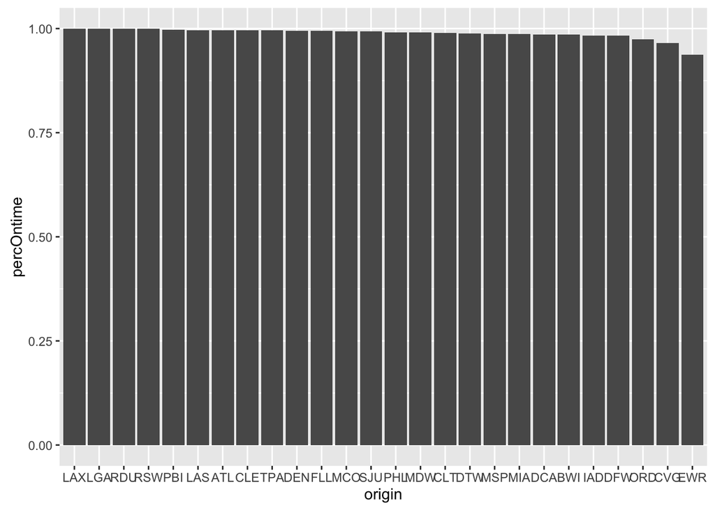

```r
toBdl3 <- bdl %>%
  mutate(arrOnTime = (arr_delay < 5 | arr_delay > -5 )) %>%
  filter(origin != "BDL")%>%
  select(origin, arrOnTime)%>%
  group_by(origin) %>%
  summarize(N = n(), numOntime = sum(arrOnTime, na.rm = TRUE))%>%
  mutate(percOntime = numOntime/N) %>%
  arrange(desc(percOntime, numOntime))

fromBdl3 <- bdl %>%
  mutate(arrOnTime = (arr_delay < 5 | arr_delay > -5))%>%
  filter(origin == "BDL")%>%
  select(dest, arrOnTime)%>%
  group_by(dest) %>%
  summarize(N = n(), numOntime = sum(arrOnTime, na.rm = TRUE))%>%
  mutate(percOntime = numOntime/N) %>%
  arrange(desc(percOntime, numOntime))

toBdl3$origin <- factor(toBdl3$origin, levels = toBdl3$origin)
arrivals <- ggplot(data = toBdl3, aes(x = origin, y = percOntime))
arrivals + geom_bar(stat = "identity")
```

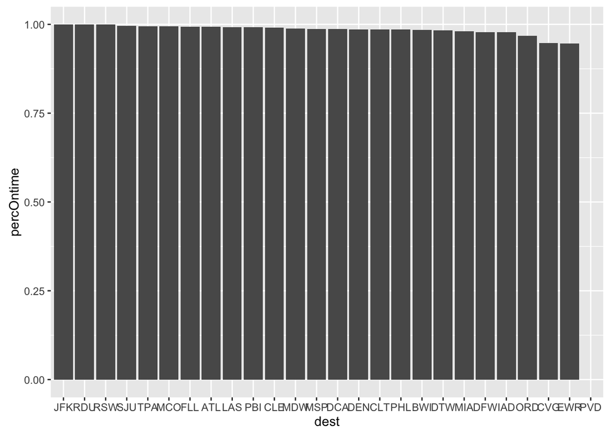

```r
fromBdl3$dest <- factor(fromBdl3$dest, levels = fromBdl3$dest)
departures <- ggplot(data = fromBdl3, aes(x = dest, y = percOntime))
departures + geom_bar(stat = "identity")
```

#### Problem 3

1. Write a function called `find_longest_delay()` that will find the flight with the longest arrival delay for a particular airline in the `bdl` data frame. Your function should take two arguments: `data`: the data frame containing the flight delay information; and `the_carrier`: a character string indicating the two-character abbreviation for the carrier you want to search. It should return a `data.frame` with a single row. Prove that your function works by finding the longest delay time for Americaa Airlines and United Airlines.

> Hint: Watch out for NA’s!!!

```r
find_longest_delay <- function(data, the_carrier){
  #finds the longest arrival delay...the largest arr_delay

  data <- data%>%
    filter(carrier == the_carrier)%>%
    arrange(desc(arr_delay))
  head(data, n = 1)
}

find_longest_delay(bdl, "AA")
```

```
## Source: local data frame [1 x 18]
##
##    year month   day dep_time dep_delay arr_time arr_delay carrier tailnum
##   (int) (int) (int)    (int)     (int)    (int)     (int)   (chr)   (chr)
## 1  2012     5    30     1414       494     1743       518      AA  N3CTAA
## Variables not shown: flight (int), origin (chr), dest (chr), air_time
##   (int), distance (int), cancelled (int), diverted (int), arrival_delayed
##   (lgl), ontime (lgl)
```

```r
find_longest_delay(bdl, "UA")
```

```
## Source: local data frame [1 x 18]
##
##    year month   day dep_time dep_delay arr_time arr_delay carrier tailnum
##   (int) (int) (int)    (int)     (int)    (int)     (int)   (chr)   (chr)
## 1  2012     8     7     1406       332     1518       317      UA  N553UA
## Variables not shown: flight (int), origin (chr), dest (chr), air_time
##   (int), distance (int), cancelled (int), diverted (int), arrival_delayed
##   (lgl), ontime (lgl)
```

The longest delay time for AA is 518 minutes. The longest delay time for UA is 317.

2. Expand your function so that it returns a helpful error message if the variable passed as `airline` is not found in the data, or if the object passed to `data` is not a `data.frame`.

```r
find_longest_delay <- function(data, the_carrier){
  #finds the longest arrival delay...the largest arr_delay

  if(the_carrier %in% data$carrier & is.data.frame(data)){
      data <- data%>%
    filter(carrier == the_carrier)%>%
    arrange(desc(arr_delay))
  head(data, n = 1)
  }

  else if(is.data.frame(data) == FALSE & the_carrier %in% data$carrier == FALSE){
    stop("You entered both a carrier that does not exist and data that is not in the form of a data frame.")
  }

  else if(is.data.frame(data) == FALSE){
    stop("You did not enter a data frame")
  }

  else{
    stop("The carrier you entered does not exist")
  }
}
```

> Hint: use *stop()*